# An Introduction to Machine Learning with R: datasets

# Edgar Anderson’s Iris Data

In R:

```r
data(iris)
```

From the `iris` manual page:

> This famous (Fisher’s or Anderson’s) iris data set gives the measurements in centimeters of the variables sepal length and width and petal length and width, respectively, for 50 flowers from each of 3 species of iris. The species are *Iris setosa*, *versicolor*, and *virginica*.

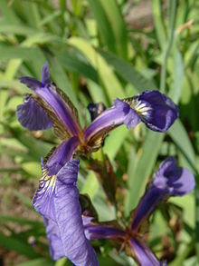

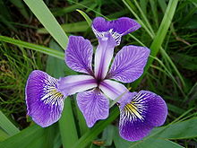

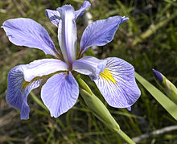

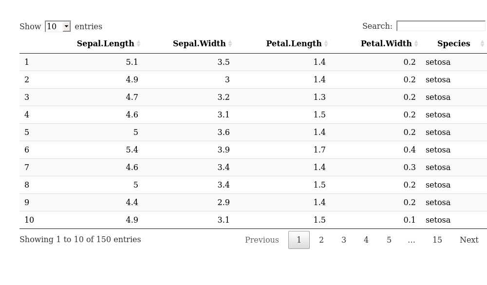

```r
datatable(iris)
```

For more details, see `?iris`.

# Motor Trend Car Road Tests

In R

```r
data(mtcars)
```

From the `?mtcars` manual page:

> The data was extracted from the 1974 *Motor Trend* US magazine, and comprises fuel consumption and 10 aspects of automobile design and performance for 32 automobiles (1973-74 models).

```r
datatable(mtcars)
```

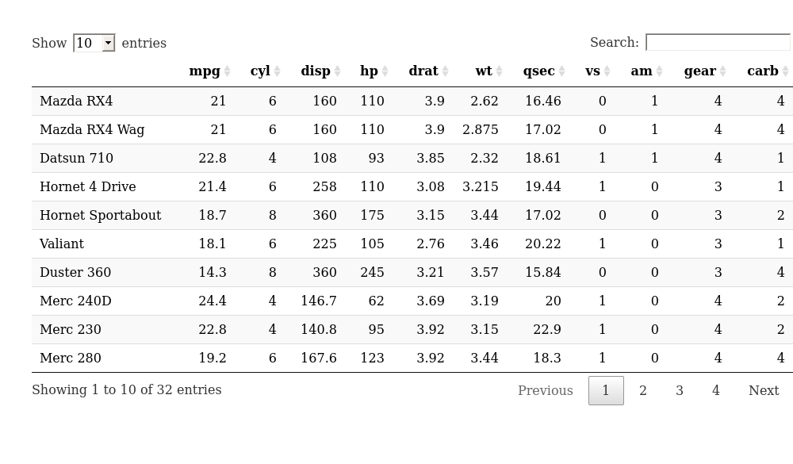

For more details, see `?mtcars`.

# Sub-cellular localisation

The `hyperLOPIT2015` data is used to demonstrate t-SNE and its comparison to PCA. These data provide sub-cellular localisation of proteins in Mouse E14TG2a embryonic stem cells, as published in [Christoforou et al. (2016)](https://doi.org/10.1038/ncomms9992).

The data comes as an `MSnSet` object from the `Biocpkg("MSnbase")` package, specifically developed for such quantitative proteomics data. Alternatively, comma-separated files containing a somehow simplified version of the data can also be found [here](https://github.com/lgatto/hyperLOPIT-csvs/).

These data are only used to illustrate some concepts and are not loaded and used directly to avoid installing numerous dependencies.

They are available through the Bioconductor project and can be installed with

```r
source("http://www.bioconductor.org/biocLite.R")
biocLite(c("MSnbsase", "pRoloc")) ## software
biocLite("pRolocdata") ## date
```

# The diamonds data

The `diamonds` data ships with the *ggplot2* package and predict the price (in US dollars) of about 54000 round cut diamonds.

In R:

```r
library("ggplot2")
data(diamonds)
```

```r
datatable(diamonds)
```

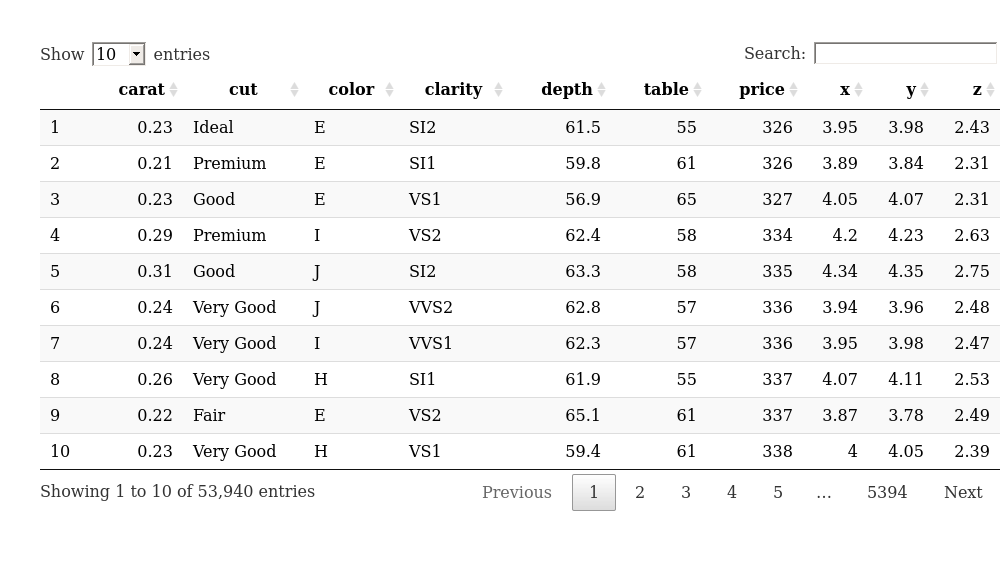

See also `?diamonds`.

# The Sonar data

The `Sonar` data from the *mlbench* package can be used to train a classifer to recognise mines from rocks using sonar data. The data is composed to 60 features representing the energy within a particular frequency band.

In R:

```r
library("mlbench")
data(Sinar)
datatable(Sonar)
```

[output not shown]

[output not shown]

```
## Error in base::rownames(data): object 'Sonar' not found
```

See also `?Sonar`.

# Housing Values in Suburbs of Boston

The `Boston` data from the *MASS* provides the median value of owner-occupied homes (`medv`) in $1000s as well as 13 other features for 506 homes in Boston.

In R:

```r
library("MASS")
data(Boston)
```

```r
datatable(Boston)
```

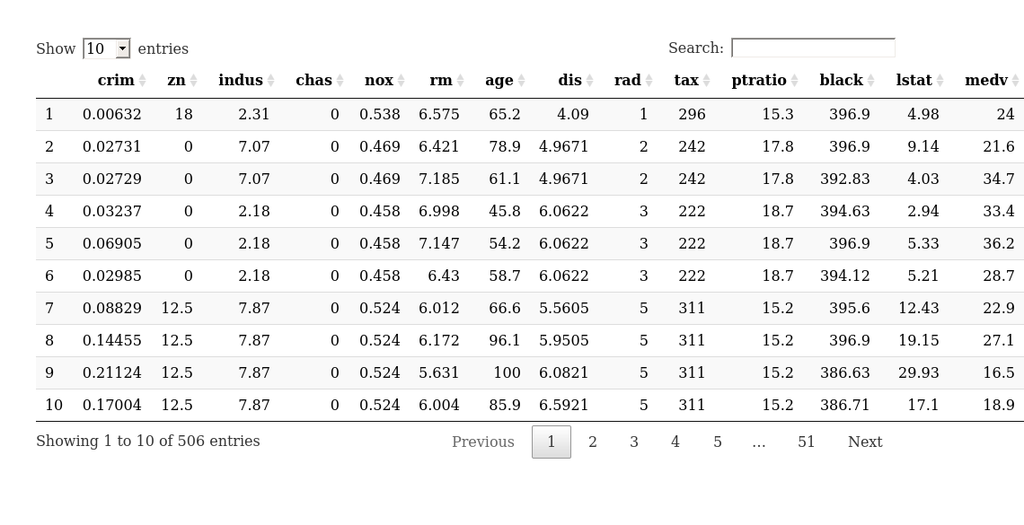

See also `?Boston`.

# Customer churn

This data from the *C50* package and distributes a training set with 3333 samples and a test set containing 1667 samples of customer attrition.

In R:

```r
library("C50")
data(churn)
dim(churnTrain)
```

```
## [1] 3333   20
```

```r
dim(churnTest)
```

```
## [1] 1667   20
```

```r
datatable(churnTrain)
```

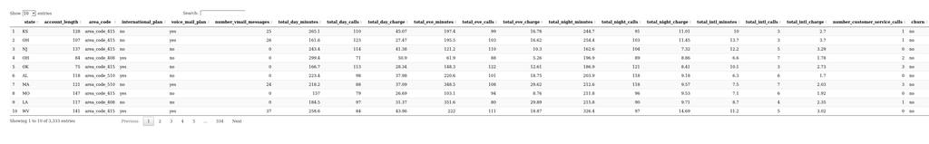